# Carga de datos

Docente: Felipe Calvo Cepeda - fcalvoc@unal.edu.co | Universidad Nacional de Colombia

## Propósito de esta práctica

Aprenderá a importar datos tabulares, verificar que se interpretaron correctamente y dejar una primera versión documentada de la base. La importación no termina cuando R muestra una tabla: hay que comprobar nombres, tipos, separadores, decimales, codificación y cantidad de observaciones.

Los archivos de esta práctica se encuentran en la carpeta data/. La misma base de obesidad está disponible en varios formatos para comparar sus diferencias.

> Una vez descargados los archivos de datos, vamos a ubicarlos al interior de una carpeta llamada **data** que a su vez crearemos dentro del directorio de nuestro proyecto.

## Paquetes para importar datos

```r
# Instalación del paquete tidyverse
# Instalación estándar (intenta esta siempre primero)
install.packages("tidyverse")

# Si la instalación falla porque el sistema indica que faltan paquetes adicionales
install.packages("tidyverse", dependencies = TRUE)

# Cargamos el paquete que acabamos de instalar
library("tidyverse")
```

Note que **tidyverse** es una colección de paquetes ampliamente usada en la ciencia de datos en R, por lo que al instalarlo se instalan a su vez numerosos paquetes que son útiles para cargar, manipular, limpiar, procesar, modelar y visualizar datos.

Veámonos cómo cargar datos en distintos formatos.

## Archivos de texto plano (.txt)

`read_delim()` permite declarar explícitamente el separador y la configuración regional.

```r
# Una forma de declararlo usando la función read_delim
data_txt <- read_delim(
  file = "data/DataObesidad.txt",
  delim = "|",
  locale=locale(decimal_mark = "."),
  na = c("", "NA", "N/A")
)

# Otra forma de declararlo usando la función read_delim
read_delim(
  file = "data/DataObesidad.txt",
  delim = "|",
  locale=locale(decimal_mark = "."),
  na = c("", "NA", "N/A")
) -> data_txt
```

```r
# Una forma de inspeccionar la estructura de los datos cargados
str(data_txt)
```

```
## spc_tbl_ [498 × 16] (S3: spec_tbl_df/tbl_df/tbl/data.frame)
##  $ Sexo                          : chr [1:498] "Mujer" "Mujer" "Hombre" "Hombre" ...
##  $ Edad                          : num [1:498] 21 21 23 27 22 29 23 22 24 22 ...
##  $ Altura                        : num [1:498] 1.62 1.52 1.8 1.8 1.78 1.62 1.5 1.64 1.78 1.72 ...
##  $ Peso                          : num [1:498] 64 56 77 87 89.8 53 55 53 64 68 ...
##  $ Antecedente_familiar_sobrepeso: chr [1:498] "si" "si" "si" "no" ...
##  $ Consume_Comidas_Altas_Calorias: chr [1:498] "no" "no" "no" "no" ...
##  $ Frecuencia_Consumo_Vegetales  : num [1:498] 2 3 2 3 2 2 3 2 3 2 ...
##  $ Comidas_Diarias               : num [1:498] 3 3 3 3 1 3 3 3 3 3 ...
##  $ Merienda                      : chr [1:498] "A veces" "A veces" "A veces" "A veces" ...
##  $ Fuma                          : chr [1:498] "no" "si" "no" "no" ...
##  $ Vasos_Agua_Diarios            : num [1:498] 2 3 2 2 2 2 2 2 2 2 ...
##  $ Monitorea_Calorias            : chr [1:498] "no" "si" "no" "no" ...
##  $ Frecuencia_Actividad_Fisica   : num [1:498] 0 3 2 2 0 0 1 3 1 1 ...
##  $ Consume_Alcohol               : chr [1:498] "no" "A veces" "Frecuentemente" "Frecuentemente" ...
##  $ Medio_Transporte              : chr [1:498] "Transporte público" "Transporte público" "Transporte público" "A pié" ...
##  $ Nivel_Peso                    : chr [1:498] "Normal" "Normal" "Normal" "Sobrepeso Nivel I" ...
##  - attr(*, "spec")=
##   .. cols(
##   ..   Sexo = col_character(),
##   ..   Edad = col_double(),
##   ..   Altura = col_double(),
##   ..   Peso = col_double(),
##   ..   Antecedente_familiar_sobrepeso = col_character(),
##   ..   Consume_Comidas_Altas_Calorias = col_character(),
##   ..   Frecuencia_Consumo_Vegetales = col_double(),
##   ..   Comidas_Diarias = col_double(),
##   ..   Merienda = col_character(),
##   ..   Fuma = col_character(),
##   ..   Vasos_Agua_Diarios = col_double(),
##   ..   Monitorea_Calorias = col_character(),
##   ..   Frecuencia_Actividad_Fisica = col_double(),
##   ..   Consume_Alcohol = col_character(),
##   ..   Medio_Transporte = col_character(),
##   ..   Nivel_Peso = col_character()
##   .. )
##  - attr(*, "problems")=<externalptr>
```

```r
# Otra forma de inspeccionar la estructura de los datos cargados
glimpse(data_txt)
```

```
## Rows: 498
## Columns: 16
## $ Sexo                           <chr> "Mujer", "Mujer", "Hombre", "Hombre", "…
## $ Edad                           <dbl> 21, 21, 23, 27, 22, 29, 23, 22, 24, 22,…
## $ Altura                         <dbl> 1.62, 1.52, 1.80, 1.80, 1.78, 1.62, 1.5…
## $ Peso                           <dbl> 64.0, 56.0, 77.0, 87.0, 89.8, 53.0, 55.…
## $ Antecedente_familiar_sobrepeso <chr> "si", "si", "si", "no", "no", "no", "si…
## $ Consume_Comidas_Altas_Calorias <chr> "no", "no", "no", "no", "no", "si", "si…
## $ Frecuencia_Consumo_Vegetales   <dbl> 2, 3, 2, 3, 2, 2, 3, 2, 3, 2, 3, 2, 3, …
## $ Comidas_Diarias                <dbl> 3, 3, 3, 3, 1, 3, 3, 3, 3, 3, 3, 3, 3, …
## $ Merienda                       <chr> "A veces", "A veces", "A veces", "A vec…
## $ Fuma                           <chr> "no", "si", "no", "no", "no", "no", "no…
## $ Vasos_Agua_Diarios             <dbl> 2, 3, 2, 2, 2, 2, 2, 2, 2, 2, 3, 2, 3, …
## $ Monitorea_Calorias             <chr> "no", "si", "no", "no", "no", "no", "no…
## $ Frecuencia_Actividad_Fisica    <dbl> 0, 3, 2, 2, 0, 0, 1, 3, 1, 1, 2, 2, 2, …
## $ Consume_Alcohol                <chr> "no", "A veces", "Frecuentemente", "Fre…
## $ Medio_Transporte               <chr> "Transporte público", "Transporte públi…
## $ Nivel_Peso                     <chr> "Normal", "Normal", "Normal", "Sobrepes…
```

Al importar archivos de texto plano conviene revisar:

- Símbolo separador
- Símbolo decimal
- Codificación
- Qué simbolos o palabras representan datos faltantes

## Archivo de valores separados por comas (.csv)

```r
read.csv(
  file = "data/DataObesidad.csv",
  na = c("", "NA", "N/A")
) -> data_csv

glimpse(data_csv)
```

```
## Rows: 498
## Columns: 16
## $ Sexo                           <chr> "Mujer", "Mujer", "Hombre", "Hombre", "…
## $ Edad                           <int> 21, 21, 23, 27, 22, 29, 23, 22, 24, 22,…
## $ Altura                         <dbl> 1.62, 1.52, 1.80, 1.80, 1.78, 1.62, 1.5…
## $ Peso                           <dbl> 64.0, 56.0, 77.0, 87.0, 89.8, 53.0, 55.…
## $ Antecedente_familiar_sobrepeso <chr> "si", "si", "si", "no", "no", "no", "si…
## $ Consume_Comidas_Altas_Calorias <chr> "no", "no", "no", "no", "no", "si", "si…
## $ Frecuencia_Consumo_Vegetales   <int> 2, 3, 2, 3, 2, 2, 3, 2, 3, 2, 3, 2, 3, …
## $ Comidas_Diarias                <int> 3, 3, 3, 3, 1, 3, 3, 3, 3, 3, 3, 3, 3, …
## $ Merienda                       <chr> "A veces", "A veces", "A veces", "A vec…
## $ Fuma                           <chr> "no", "si", "no", "no", "no", "no", "no…
## $ Vasos_Agua_Diarios             <int> 2, 3, 2, 2, 2, 2, 2, 2, 2, 2, 3, 2, 3, …
## $ Monitorea_Calorias             <chr> "no", "si", "no", "no", "no", "no", "no…
## $ Frecuencia_Actividad_Fisica    <int> 0, 3, 2, 2, 0, 0, 1, 3, 1, 1, 2, 2, 2, …
## $ Consume_Alcohol                <chr> "no", "A veces", "Frecuentemente", "Fre…
## $ Medio_Transporte               <chr> "Transporte público", "Transporte públi…
## $ Nivel_Peso                     <chr> "Normal", "Normal", "Normal", "Sobrepes…
```

Al importar archivos separados por comas revisar:

- Símbolo separador (*no siempre se separan con comas*)
- Símbolo decimal
- Codificación
- Qué simbolos o palabras representan datos faltantes

## Archivos de Excel (.xls .xlsx)

```r
library("readxl")
read_excel(
  path = "data/DataObesidad.xls"
) -> data_xls

str(data_xls)
```

```
## tibble [498 × 16] (S3: tbl_df/tbl/data.frame)
##  $ Sexo                          : chr [1:498] "Mujer" "Mujer" "Hombre" "Hombre" ...
##  $ Edad                          : num [1:498] 21 21 23 27 22 29 23 22 24 22 ...
##  $ Altura                        : num [1:498] 1.62 1.52 1.8 1.8 1.78 1.62 1.5 1.64 1.78 1.72 ...
##  $ Peso                          : num [1:498] 64 56 77 87 89.8 53 55 53 64 68 ...
##  $ Antecedente_familiar_sobrepeso: chr [1:498] "si" "si" "si" "no" ...
##  $ Consume_Comidas_Altas_Calorias: chr [1:498] "no" "no" "no" "no" ...
##  $ Frecuencia_Consumo_Vegetales  : num [1:498] 2 3 2 3 2 2 3 2 3 2 ...
##  $ Comidas_Diarias               : num [1:498] 3 3 3 3 1 3 3 3 3 3 ...
##  $ Merienda                      : chr [1:498] "A veces" "A veces" "A veces" "A veces" ...
##  $ Fuma                          : chr [1:498] "no" "si" "no" "no" ...
##  $ Vasos_Agua_Diarios            : num [1:498] 2 3 2 2 2 2 2 2 2 2 ...
##  $ Monitorea_Calorias            : chr [1:498] "no" "si" "no" "no" ...
##  $ Frecuencia_Actividad_Fisica   : num [1:498] 0 3 2 2 0 0 1 3 1 1 ...
##  $ Consume_Alcohol               : chr [1:498] "no" "A veces" "Frecuentemente" "Frecuentemente" ...
##  $ Medio_Transporte              : chr [1:498] "Transporte público" "Transporte público" "Transporte público" "A pié" ...
##  $ Nivel_Peso                    : chr [1:498] "Normal" "Normal" "Normal" "Sobrepeso Nivel I" ...
```

```r
read_xlsx(
  path = "data/DataObesidad.xlsx",
  sheet= "Obesidad"
) -> data_xlsx

dim(data_xlsx)
```

```
## [1] 498  16
```

```r
names(data_xlsx)
```

```
##  [1] "Sexo"                           "Edad"
##  [3] "Altura"                         "Peso"
##  [5] "Antecedente_familiar_sobrepeso" "Consume_Comidas_Altas_Calorias"
##  [7] "Frecuencia_Consumo_Vegetales"   "Comidas_Diarias"
##  [9] "Merienda"                       "Fuma"
## [11] "Vasos_Agua_Diarios"             "Monitorea_Calorias"
## [13] "Frecuencia_Actividad_Fisica"    "Consume_Alcohol"
## [15] "Medio_Transporte"               "Nivel_Peso"
```

```r
glimpse(data_xlsx)
```

```
## Rows: 498
## Columns: 16
## $ Sexo                           <chr> "Mujer", "Mujer", "Hombre", "Hombre", "…
## $ Edad                           <dbl> 21, 21, 23, 27, 22, 29, 23, 22, 24, 22,…
## $ Altura                         <dbl> 1.62, 1.52, 1.80, 1.80, 1.78, 1.62, 1.5…
## $ Peso                           <dbl> 64.0, 56.0, 77.0, 87.0, 89.8, 53.0, 55.…
## $ Antecedente_familiar_sobrepeso <chr> "si", "si", "si", "no", "no", "no", "si…
## $ Consume_Comidas_Altas_Calorias <chr> "no", "no", "no", "no", "no", "si", "si…
## $ Frecuencia_Consumo_Vegetales   <dbl> 2, 3, 2, 3, 2, 2, 3, 2, 3, 2, 3, 2, 3, …
## $ Comidas_Diarias                <dbl> 3, 3, 3, 3, 1, 3, 3, 3, 3, 3, 3, 3, 3, …
## $ Merienda                       <chr> "A veces", "A veces", "A veces", "A vec…
## $ Fuma                           <chr> "no", "si", "no", "no", "no", "no", "no…
## $ Vasos_Agua_Diarios             <dbl> 2, 3, 2, 2, 2, 2, 2, 2, 2, 2, 3, 2, 3, …
## $ Monitorea_Calorias             <chr> "no", "si", "no", "no", "no", "no", "no…
## $ Frecuencia_Actividad_Fisica    <dbl> 0, 3, 2, 2, 0, 0, 1, 3, 1, 1, 2, 2, 2, …
## $ Consume_Alcohol                <chr> "no", "A veces", "Frecuentemente", "Fre…
## $ Medio_Transporte               <chr> "Transporte público", "Transporte públi…
## $ Nivel_Peso                     <chr> "Normal", "Normal", "Normal", "Sobrepes…
```

Al importar datos desde Excel, asegúrese de especificar el nombre exacto de la hoja que contiene sus **datos brutos**. La hoja de datos debe contener una tabla rectangular: una fila de encabezados, una observación por fila y una variable por columna.

Para explorar las hojas disponibles dentro de un archivo:

```r
excel_sheets("data/DataObesidad.xlsx")
```

```
## [1] "Obesidad"
```

## Stata (.dta) y SPSS (.sav)

`haven` permite importar formatos usados frecuentemente en investigación social y económica.

```r
library(haven)

data_dta <- read_dta("data/DataObesidad.dta")
data_sav <- read_sav("data/DataObesidad.sav")

glimpse(data_dta)
```

```
## Rows: 498
## Columns: 16
## $ Sexo                           <chr> "Mujer", "Mujer", "Hombre", "Hombre", "…
## $ Edad                           <dbl> 21, 21, 23, 27, 22, 29, 23, 22, 24, 22,…
## $ Altura                         <dbl> 1.62, 1.52, 1.80, 1.80, 1.78, 1.62, 1.5…
## $ Peso                           <dbl> 64.0, 56.0, 77.0, 87.0, 89.8, 53.0, 55.…
## $ Antecedente_familiar_sobrepeso <chr> "si", "si", "si", "no", "no", "no", "si…
## $ Consume_Comidas_Altas_Calorias <chr> "no", "no", "no", "no", "no", "si", "si…
## $ Frecuencia_Consumo_Vegetales   <dbl> 2, 3, 2, 3, 2, 2, 3, 2, 3, 2, 3, 2, 3, …
## $ Comidas_Diarias                <dbl> 3, 3, 3, 3, 1, 3, 3, 3, 3, 3, 3, 3, 3, …
## $ Merienda                       <chr> "A veces", "A veces", "A veces", "A vec…
## $ Fuma                           <chr> "no", "si", "no", "no", "no", "no", "no…
## $ Vasos_Agua_Diarios             <dbl> 2, 3, 2, 2, 2, 2, 2, 2, 2, 2, 3, 2, 3, …
## $ Monitorea_Calorias             <chr> "no", "si", "no", "no", "no", "no", "no…
## $ Frecuencia_Actividad_Fisica    <dbl> 0, 3, 2, 2, 0, 0, 1, 3, 1, 1, 2, 2, 2, …
## $ Consume_Alcohol                <chr> "no", "A veces", "Frecuentemente", "Fre…
## $ Medio_Transporte               <chr> "Transporte público", "Transporte públi…
## $ Nivel_Peso                     <chr> "Normal", "Normal", "Normal", "Sobrepes…
```

```r
glimpse(data_sav)
```

```
## Rows: 498
## Columns: 16
## $ Sexo                           <chr> "Mujer", "Mujer", "Hombre", "Hombre", "…
## $ Edad                           <dbl> 21, 21, 23, 27, 22, 29, 23, 22, 24, 22,…
## $ Altura                         <dbl> 1.62, 1.52, 1.80, 1.80, 1.78, 1.62, 1.5…
## $ Peso                           <dbl> 64.0, 56.0, 77.0, 87.0, 89.8, 53.0, 55.…
## $ Antecedente_familiar_sobrepeso <chr> "si", "si", "si", "no", "no", "no", "si…
## $ Consume_Comidas_Altas_Calorias <chr> "no", "no", "no", "no", "no", "si", "si…
## $ Frecuencia_Consumo_Vegetales   <dbl> 2, 3, 2, 3, 2, 2, 3, 2, 3, 2, 3, 2, 3, …
## $ Comidas_Diarias                <dbl> 3, 3, 3, 3, 1, 3, 3, 3, 3, 3, 3, 3, 3, …
## $ Merienda                       <chr> "A veces", "A veces", "A veces", "A vec…
## $ Fuma                           <chr> "no", "si", "no", "no", "no", "no", "no…
## $ Vasos_Agua_Diarios             <dbl> 2, 3, 2, 2, 2, 2, 2, 2, 2, 2, 3, 2, 3, …
## $ Monitorea_Calorias             <chr> "no", "si", "no", "no", "no", "no", "no…
## $ Frecuencia_Actividad_Fisica    <dbl> 0, 3, 2, 2, 0, 0, 1, 3, 1, 1, 2, 2, 2, …
## $ Consume_Alcohol                <chr> "no", "A veces", "Frecuentemente", "Fre…
## $ Medio_Transporte               <chr> "Transporte público", "Transporte públi…
## $ Nivel_Peso                     <chr> "Normal", "Normal", "Normal", "Sobrepes…
```

Estos formatos pueden conservar etiquetas y atributos que no aparecen al importar un CSV. Revise la clase de las variables y no convierta automáticamente todos los textos en factores sin entender su significado.

## Desde el portapapeles (matrices)

```r
data_copiada <- read.delim("clipboard", header=TRUE)

glimpse(data_copiada)
```

## Hojas de cálculo en Google Sheets

Podemos leer desde R hojas de cálculo públicas o privadas.

### Hojas públicas

Hojas pública que no necesitan autenticación y están compartidas de forma pública o a usuarios que tengan el enlace.

```r
library("googlesheets4")
# Comando para que no nos exija autenticación
gs4_deauth()
# Declaro el enlace
link = "https://docs.google.com/spreadsheets/d/1iM7i0nd3EPMzH79oZEo48nIcWbyT14ThsJ8ZO9r3F4Y/edit?usp=sharing"
# Lectura de datos
data_gs <- read_sheet(link)

str(data_gs)
```

### Hojas privadas

Para una hoja privada se requiere autenticación interactiva; no se deben guardar tokens ni credenciales en el script.

```r
# library("googlesheets4")
# Comando para realizar la autenticación vía web
gs4_auth()
# Declaro el enlace
link = "https://docs.google.com/spreadsheets/d/1iM7i0nd3EPMzH79oZEo48nIcWbyT14ThsJ8ZO9r3F4Y/edit?usp=sharing"
# Lectura de datos
data_gs <- read_sheet(link)

str(boston_housing_gs)
```

## Usando la interfaz de RStudio

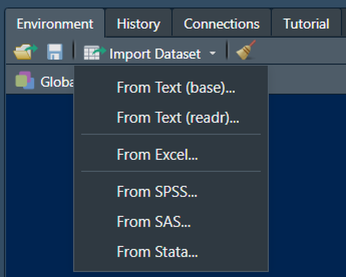

## Verificación mínima después de importar

```r
verificar_base <- function(x) {
  tibble(
    filas = nrow(x),
    columnas = ncol(x),
    faltantes = sum(is.na(x)),
    nombres_unicos = n_distinct(names(x)) == ncol(x)
  )
}

verificar_base(data_xlsx)
```

```
## # A tibble: 1 × 4
##   filas columnas faltantes nombres_unicos
##   <int>    <int>     <int> <lgl>
## 1   498       16         0 TRUE
```

```r
map(data_xlsx, class)
```

```
## $Sexo
## [1] "character"
##
## $Edad
## [1] "numeric"
##
## $Altura
## [1] "numeric"
##
## $Peso
## [1] "numeric"
##
## $Antecedente_familiar_sobrepeso
## [1] "character"
##
## $Consume_Comidas_Altas_Calorias
## [1] "character"
##
## $Frecuencia_Consumo_Vegetales
## [1] "numeric"
##
## $Comidas_Diarias
## [1] "numeric"
##
## $Merienda
## [1] "character"
##
## $Fuma
## [1] "character"
##
## $Vasos_Agua_Diarios
## [1] "numeric"
##
## $Monitorea_Calorias
## [1] "character"
##
## $Frecuencia_Actividad_Fisica
## [1] "numeric"
##
## $Consume_Alcohol
## [1] "character"
##
## $Medio_Transporte
## [1] "character"
##
## $Nivel_Peso
## [1] "character"
```

Si una columna numérica se importó como texto, no la convierta a ciegas: busque símbolos de moneda, separadores de miles, espacios y valores especiales que expliquen el problema.

## Lista de verificación

- La ruta es relativa al proyecto.
- La tabla tiene encabezados y una observación por fila.
- Los nombres de las variables son únicos.
- Las clases de las variables son razonables.
- Se revisó el número de filas y columnas.
- Se contabilizaron los valores faltantes (lo vamos a aprender en la próxima practica).
- Se documentó el formato original y la fuente de los datos.

> Ya sabemos importar datos.